# Explainable AI: SHAP

## By Kenneth Lim, 2021-09-23

## Content

1. What is SHAP and How to Use It?
2. SHAP Concepts
   - Shapley Values
   - SHAP Properties
3. SHAP from Scratch
   - TreeSHAP

# 1. What is SHAP and How to Use It?

SHAP is a method to explain individual predictions. SHAP is based on the game theoretically optimal Shapley Values.

The goal of SHAP is to explain the prediction of an instance x by computing the contribution of each feature to the prediction.

Example:

Train simple decision tree model.

```python
import pandas as pd
from sklearn.datasets import load_boston

dataset = load_boston()
features = ['RM', 'LSTAT', 'DIS', 'NOX']
df = pd.DataFrame(dataset.data, columns=dataset.feature_names)
X = df[features]
y = dataset.target


from sklearn.tree import DecisionTreeRegressor

clf = DecisionTreeRegressor(max_depth=3)
clf.fit(X, y)
```

```
DecisionTreeRegressor(max_depth=3)
```

## 1.1 Global: Feature Importance

Here the absolute value of the SHAP values are averaged to give the overall importance.

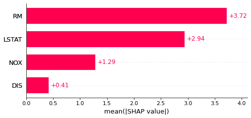

```python
import shap

explainer = shap.Explainer(clf, X)
shap_values = explainer(X)

# Global interpretation
shap.plots.bar(shap_values)
```

## 1.2 Global: Impact on model output

Beeswarm plot can be used to analyse feature impact on final prediction at global level.

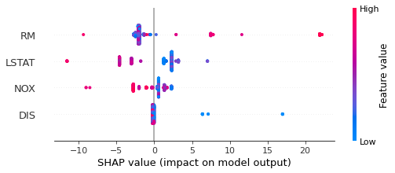

```python
# Global interpretation: Feature Importance
shap.plots.beeswarm(shap_values)
```

## 1.3 Global: Partial Dependence plots

Analyse the relationship of a feature w.r.t to target variable

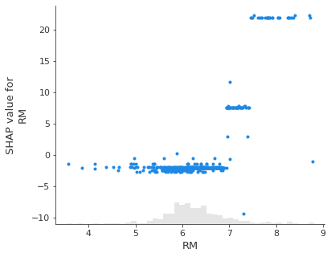

```python
shap.plots.scatter(shap_values[:,"RM"])
```

## 1.4 Local: Single Instance Explaination using Waterfall chart

SHAP can be used to analyse deeper at single instance level. Can be explained in terms of each feature's contribution to the final overall predicted value.

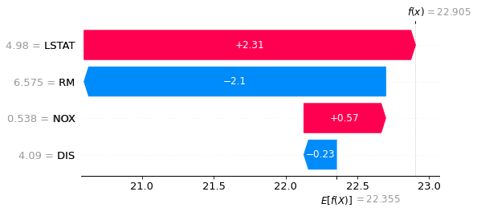

```python
# Local interpretation
shap.plots.waterfall(shap_values[0])
```

# 2. SHAP Concepts

## 2.1 Shapley Values

Shapley values – a method from coalitional game theory – tells us how to fairly distribute the “payout” among the features.

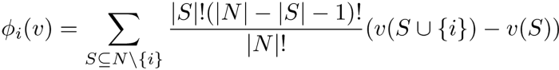

```python
from IPython.display import Image

Image('img/shapley_formula.png', width=500)
```

#### Example

Alice, Bob and Celine share a meal. We want to find out what's the fair amount that each person should pay?

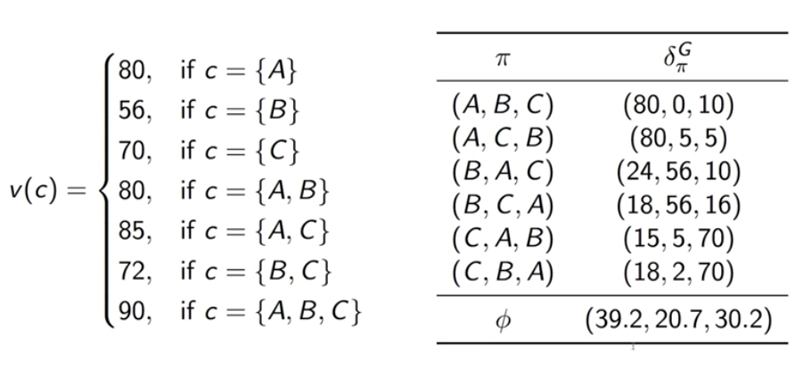

```python
Image('img/coalition_table.png', width=600)
```

## 2.2 SHAP Properties

### 2.2.1 Local Accuracy

SHAP efficiency property: Additive property of SHAP values and SHAP Intercept to give the prediction value.

$$ f(x) = g(x') = \phi_0 + \sum_{j=1}^{M}{\phi_j x'_j} = E_X\lbrack \hat{f}(X) \rbrack + \sum_{j=1}^{M}{\phi_j} $$

### 2.2.2 Missingness

Missingness says that a missing feature gets an attribution of zero. $x′_j$ refers to the coalitions, where a value of 0 represents the absence of a feature value. The Missingness property enforces that missing features get a Shapley value of 0.

$$ x'_j = 0 \Rightarrow \phi_j = 0 $$

### 2.2.3 Consistency

Let $f_x(z') = f(h_x(z'))$. For any two models $f$ and $f'$ that satisfy $f'_x(z') - f'_x(z'_{\j}) \ge f_x(z') - f_x(z'_{\j})$,

for all inputs $z' \in \{0,1\}^M$, then $\phi(f', x) \ge \phi(f, x)$.

As long as the marginal value of a feature for two models are consistent, the SHAP values of feature from both models will be consistent (feature importance / SHAP value higher or stay the same)

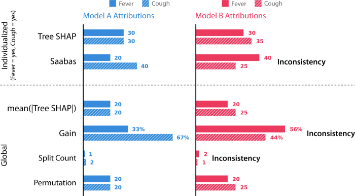

```python
Image('img/example_inconsistency.png', width=500)
```

# 3. SHAP from Scratch

## 3.1 TreeSHAP

TreeSHAP Algorithm:

- TreeSHAP uses the conditional expectation to estimate effects.
- If we conditioned on all features, then the prediction from the node in which the instance x falls would be the expected prediction.
- If we did no condition on any feature, use the weighted average of predictions of all terminal nodes.
- If S contains some features, we average the predictions weighted by node sizes.

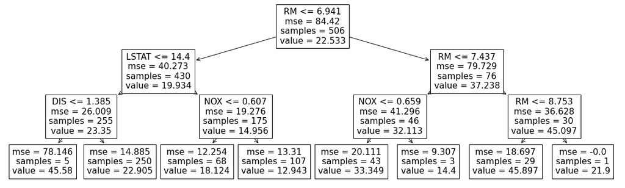

```python
import matplotlib.pyplot as plt
import shap

from sklearn.tree import plot_tree

plt.figure(figsize=(20,6))
plot_tree(clf, feature_names=X.columns);
```

```python
import shap

explainer = shap.TreeExplainer(clf)
shap_values = explainer.shap_values(X[:1])
```

```python
pd.DataFrame({'feature_name': X.columns,
              'feature_values': X.loc[0],
              'shap_values': shap_values.squeeze()})
```

|  | feature_name | feature_values | shap_values |
| --- | --- | --- | --- |
| RM | RM | 6.575 | -2.395304 |
| LSTAT | LSTAT | 4.980 | 2.461312 |
| DIS | DIS | 4.090 | -0.329802 |
| NOX | NOX | 0.538 | 0.636187 |

```python
from itertools import combinations

def make_coalitions(row, shap_feature):
    features = row.index
    S_feat = [f for f in features if f != shap_feature]

    all_comb = []
    for i in range(len(S_feat) + 1):
        for x in combinations(S_feat, i):
            comb = list(x)
            all_comb.append(comb)

    return all_comb

feature = 'RM'
x = X.loc[0]
make_coalitions(x, feature)
```

```
[[],
 ['LSTAT'],
 ['DIS'],
 ['NOX'],
 ['LSTAT', 'DIS'],
 ['LSTAT', 'NOX'],
 ['DIS', 'NOX'],
 ['LSTAT', 'DIS', 'NOX']]
```

```python
def pred_tree(clf, coalition, row, node=0):
    left_node = clf.tree_.children_left[node]
    right_node = clf.tree_.children_right[node]
    is_leaf = left_node == right_node

    if is_leaf:
        return clf.tree_.value[node].squeeze()

    feature = row.index[clf.tree_.feature[node]]
    if feature in coalition:
        if row.loc[feature] <= clf.tree_.threshold[node]:
            # go left
            return pred_tree(clf, coalition, row, node=left_node)
        # go right
        return pred_tree(clf, coalition, row, node=right_node)

    # take weighted average of left and right
    wl = clf.tree_.n_node_samples[left_node] / clf.tree_.n_node_samples[node]
    wr = clf.tree_.n_node_samples[right_node] / clf.tree_.n_node_samples[node]
    value = wl * pred_tree(clf, coalition, row, node=left_node)
    value += wr * pred_tree(clf, coalition, row, node=right_node)
    return value
```

```python
import scipy

def make_value_function(clf, row, shap_feature):
    def value(coalition):
        marginal_gain = pred_tree(clf, coalition + [shap_feature], row) - pred_tree(clf, coalition, row)
        num_coalitions = scipy.special.comb(len(row) - 1, len(coalition))
        return marginal_gain / num_coalitions
    return value

def compute_shap(clf, row, shap_feature):
    v = make_value_function(clf, row, shap_feature)
    n_features = len(row)
    return sum([v(coal) / n_features for coal in make_coalitions(row, shap_feature)])
```

```python
pd.DataFrame({'feature_name': X.columns,
              'feature_values': X.loc[0],
              'shap_values': shap_values.squeeze(),
              'afiodorov_shap_values': [compute_shap(clf, x, f) for f in X.columns]})
```

|  | feature_name | feature_values | shap_values | afiodorov_shap_values |
| --- | --- | --- | --- | --- |
| RM | RM | 6.575 | -2.395304 | -2.395304 |
| LSTAT | LSTAT | 4.980 | 2.461312 | 2.461312 |
| DIS | DIS | 4.090 | -0.329802 | -0.329802 |
| NOX | NOX | 0.538 | 0.636187 | 0.636187 |

## Thank you!

### References

- [Interpretable Machine Learning - Online Book](https://christophm.github.io/interpretable-ml-book/)
- [Explainable AI with Shapley values - Offical SHAP Documentation](https://shap.readthedocs.io/en/latest/example_notebooks/overviews/An%20introduction%20to%20explainable%20AI%20with%20Shapley%20values.html)
- [Cooperative Games and Shapley Value - YouTube](https://www.youtube.com/watch?v=w9O0fkfMkx0)
- [Making Sense of Shapley Values - Medium Blog](https://towardsdatascience.com/making-sense-of-shapley-values-dc67a8e4c5e8)
- [Interpretable Machine Learning with XGBoost - Scott Lundberg](https://towardsdatascience.com/interpretable-machine-learning-with-xgboost-9ec80d148d27)
- [Computing SHAP values from scratch](https://afiodorov.github.io/2019/05/20/shap-values-explained/)